# Exploración de los datos y PCA

Marta Martínez Guerra

17/5/2023

# 1 Librerías utilizadas

```r
library(dplyr)
library(GGally)
library(ggplot2)
library(ggcorrplot)
library(FactoMineR)
library(factoextra)
library(psych)
library(tidyverse)
```

# 2 Juego de datos

- Attribution 4.0 International (CC BY 4.0)
- Author: desconocido
- Disponible en [kaggle](https://www.kaggle.com/datasets/rkiattisak/mobile-phone-price)

# 3 Exploración de los datos.

A continuación, podemos ver una tabla que muestra los estadísticos básicos de cada variable, valores mínimos, máximos, media, y mediana, vemos que en todas las variables hay valores por encima del primer y tercer cuartil, en concreto en Price, vemos que el corte del tercer cuartil se sitúa en 499 y el máximo son 1999

```r
knitr::kable(summary(datos1[,4:8]))
```

|  | Storage | RAM | Screen.Size | Battery | Price |
| --- | --- | --- | --- | --- | --- |
|  | Min. : 32.0 | Min. : 2.000 | Min. :4.500 | Min. :1821 | Min. : 99.0 |
|  | 1st Qu.: 64.0 | 1st Qu.: 4.000 | 1st Qu.:6.440 | 1st Qu.:4300 | 1st Qu.: 199.0 |
|  | Median :128.0 | Median : 6.000 | Median :6.500 | Median :5000 | Median : 299.0 |
|  | Mean :124.6 | Mean : 5.879 | Mean :6.476 | Mean :4684 | Mean : 411.7 |
|  | 3rd Qu.:128.0 | 3rd Qu.: 8.000 | 3rd Qu.:6.580 | 3rd Qu.:5000 | 3rd Qu.: 499.0 |
|  | Max. :512.0 | Max. :16.000 | Max. :7.600 | Max. :7000 | Max. :1999.0 |

## 3.1 ¿Cuántos modelos de móvil tenemos en cada compañía?

Tenemos 16 marcas diferentes, las que menos modelos tienen son CAT y Soni con 1 modelo, y la que más tiene es Samsung con 73 modelos.

```r
knitr::kable(datos1 %>%
  group_by(Brand)%>%
  summarize(Total = n())%>%
  arrange(Total))
```

| Brand | Total |
| --- | --- |
| CAT | 1 |
| Sony | 1 |
| Blackberry | 3 |
| LG | 3 |
| Asus | 4 |
| Google | 5 |
| Huawei | 12 |
| OnePlus | 14 |
| Motorola | 22 |
| Nokia | 24 |
| Apple | 28 |
| Vivo | 33 |
| Realme | 43 |
| Oppo | 53 |
| Xiaomi | 62 |
| Samsung | 73 |

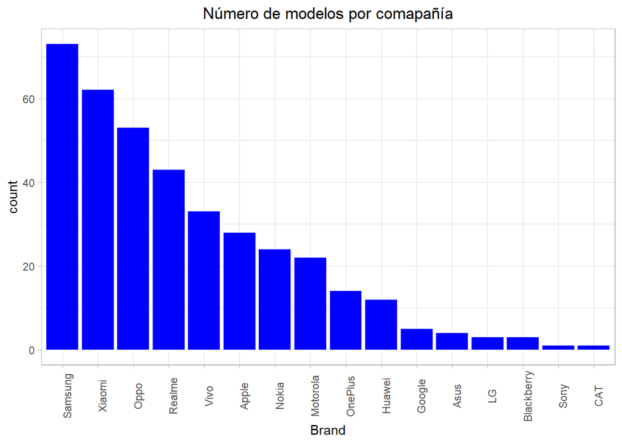

```r
level<- (c("Samsung", "Xiaomi", "Oppo","Realme", "Vivo","Apple","Nokia", "Motorola", "OnePlus",
           "Huawei","Google", "Asus", "LG", "Blackberry", "Sony", "CAT"))

datos1$Brand <- factor(datos1$Brand, levels=level)

datos1 %>%
  ggplot(aes(Brand)) +
  geom_bar(fill="blue")+
  theme_light()+
  theme(axis.text.x =element_text(angle= 90))+
  ggtitle("Número de modelos por comapañía")+
  theme(plot.title = element_text(hjust = 0.5))
```

## 3.2 Gráfico de las variables numéricas por pares

En este gráfico se muestra la distribución de cada variable, vemos que en algunos atributos aparece asimetría, en Price la cola está hacia la derecha y la mayor parte de los valores son menores de 500, en Screen Size tenemos un recorrido intercuartílico muy pequeño y vemos que los valores que se sitúan entre el primer y el tercer cuartil están entre 6.44 y 6.59, en los gráficos de dispersión podemos ver que algunas de las variables muestran una correlación positiva como es el caso de Storage y RAM, Storage y RAM con Price, Screen.Size con Battery, y correlación negativa como en el caso de las variables Battery y Price.

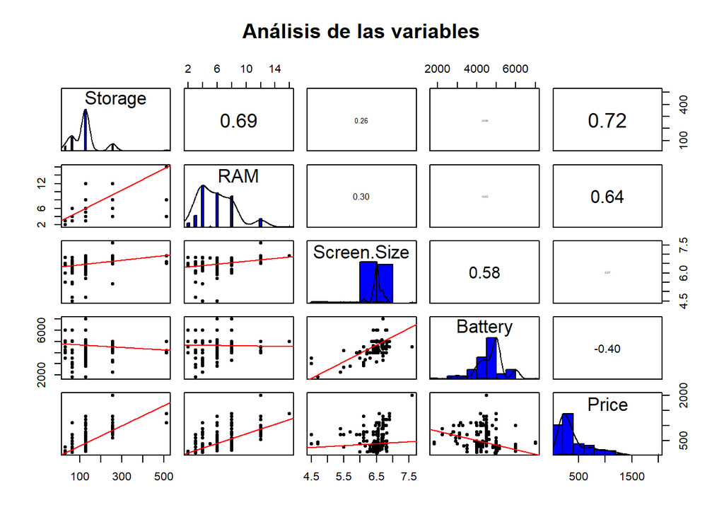

```r
pairs.panels(datos1[,4:8], scale = TRUE, density = TRUE, ellipses = FALSE,
             lm = TRUE, method = 'pearson', hist.col = 'blue', main = 'Análisis de las variables')
```

## 3.3 Estudio de los valores outliers

En todas las variables aparecen valores atípicos, pero hay que destacar el caso de Price en el que aparece un gran número de valores por encima de 500 y el caso de Screen.Size en el que recorrido intercuartílico es muy pequeño y se sitúa en torno al 6.5.

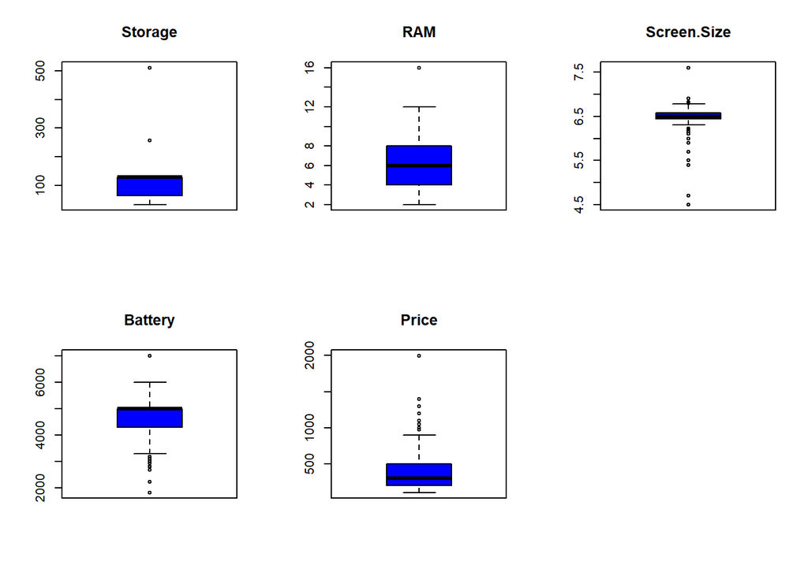

```r
par(mfrow=c(2,3))
boxplot(datos1$Storage,col="blue", main = "Storage")
boxplot(datos1$RAM,col="blue",  main = "RAM")
boxplot(datos1$Screen.Size,col="blue",  main = "Screen.Size")
boxplot(datos1$Battery,col="blue",  main = "Battery")
boxplot(datos1$Price,col="blue" , main = "Price")
```

## 3.4 Correlación

En este gráfico vemos con más detalle la correlación existente entre las variables que ya se mostraba en los gráficos de dispersión.

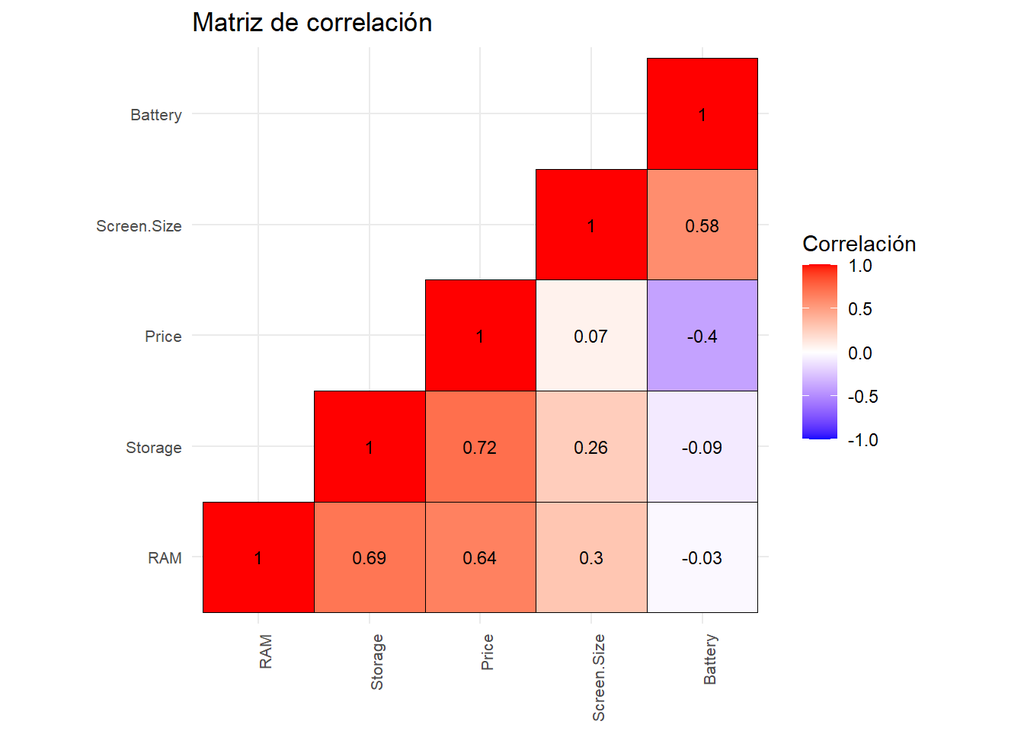

```r
correl <- cor(datos1[,4:8], use = "complete.obs")


ggcorrplot(correl, method = "square", type = "lower",hc.order = TRUE, hc.method = "complete",
           ggtheme = ggplot2::theme_minimal, title = "Matriz de correlación",show.legend = TRUE,
           legend.title = "Correlación", show.diag = TRUE,colors = c("blue", "white", "red"),
           outline.color = "black", lab = TRUE,lab_col = "black", lab_size = 3,
           p.mat = NULL, sig.level = 0.05,insig = c("pch", "blank"), pch = 4, pch.col = "black",
           pch.cex = 5, tl.cex = 8, tl.col = "black", tl.srt = 90)
```

## 3.5 Gráficos de Dispersión

Dentro de cada marca encontramos una correlación distinta, en el caso de RAM y Storage vemos que algunas empresas tienen una correlación alta mientras que en otras la recta se sitúa casi en el plano horizontal, en el gráfico de Price y Battery incluso podemos ver algunas rectas que muestran una pendiente positiva y otras negativas.

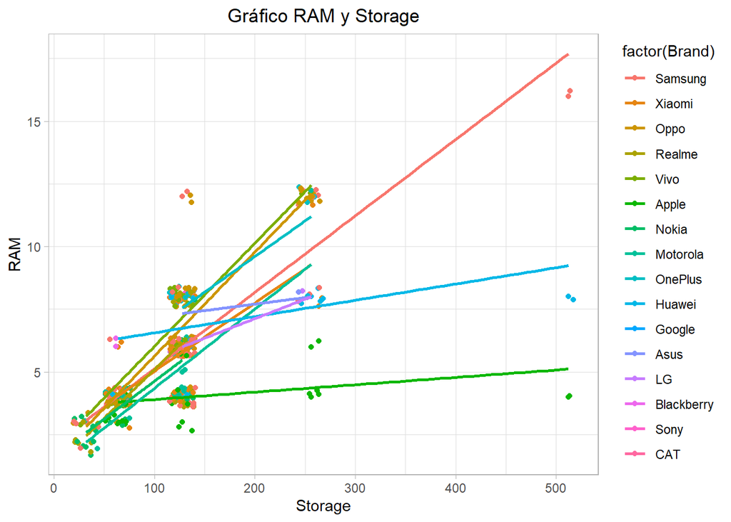

```r
ggplot(datos1, aes(Storage, RAM, color= factor(Brand))) +
  geom_point()+
  geom_jitter()+
  theme_light() +
  ggtitle("Gráfico RAM y Storage")+
  theme(plot.title = element_text(hjust = 0.5))+
  geom_smooth(method = lm, se = FALSE)
```

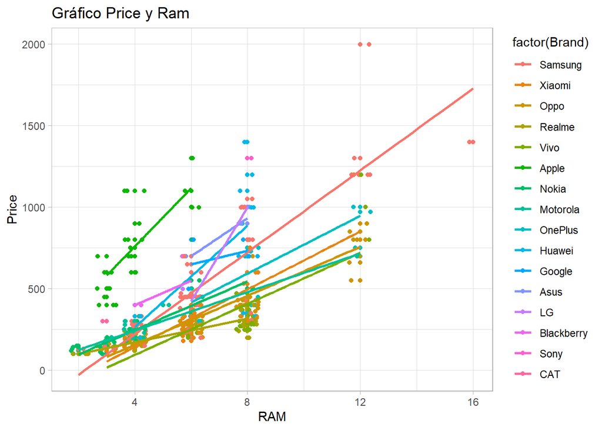

```r
ggplot(datos1, aes(RAM, Price, color= factor(Brand))) +
  geom_point()+
  geom_jitter()+
  theme_light()+
  labs(title = "Gráfico Price y Ram")+
  geom_smooth(method = lm, se = FALSE)
```

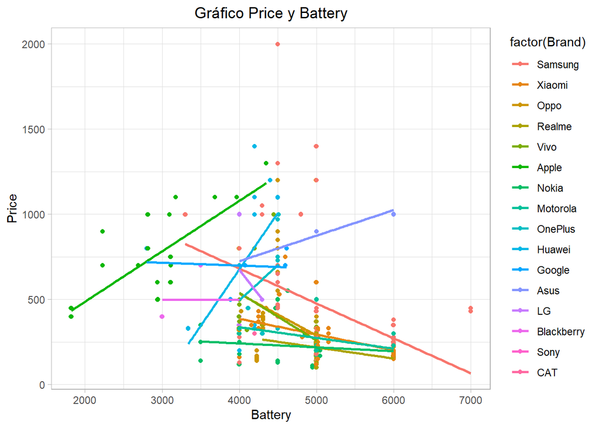

```r
ggplot(datos1, aes(Battery, Price, color= factor(Brand))) +
  geom_point()+
  geom_jitter()+
  theme_light() +
  ggtitle("Gráfico Price y Battery")+
  theme(plot.title = element_text(hjust = 0.5))+
  geom_smooth(method = lm, se = FALSE)
```

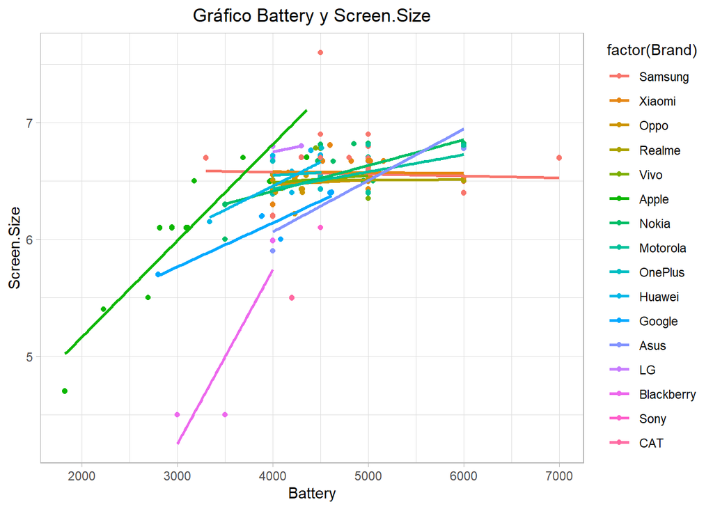

```r
ggplot(datos1, aes(Battery, Screen.Size, color= factor(Brand))) +
  geom_point()+
  geom_jitter()+
  theme_light()+
  ggtitle("Gráfico Battery y Screen.Size")+
  theme(plot.title = element_text(hjust = 0.5))+
  geom_smooth(method = lm, se = FALSE)
```

# 4 Normalización de los atributos.

```r
datos1.2 <- datos1
```

```r
datos1.2[,c("Storage")] <- (datos1$Storage-mean(datos1$Storage))/sd(datos1$Storage)
 datos1.2[,c("RAM")] <- (datos1$RAM-mean(datos1$RAM))/sd(datos1$RAM)
 datos1.2[,c("Screen.Size")] <- (datos1$Screen.Size-mean(datos1$Screen.Size))/sd(datos1$Screen.Size)
 datos1.2[,c("Battery")] <- (datos1$Battery- mean(datos1$Battery))/sd(datos1$Battery)
 datos1.2[,c("Price")] <- (datos1$Price-mean(datos1$Price))/sd(datos1$Price)
```

Para explorar los datos e identificar los grupos con características similares utilizamos un metodo de reducción de la dimensionalidad llamado Principal Component Analysis.

# 5 Principal Component Analysis PCA

Este método de reducción de la dimensionalidad reestructura los datos de tal manera que nos permite visualizar con dos componentes o variables la mayor parte de la variación de los datos, y detectar algunos patrones.

```r
datos_pca <- PCA(datos1.2[,4:8], ncp = 5, graph = FALSE)
```

## 5.1 Resumen del objeto PCA

```r
knitr::kable(summary(datos_pca))
```

```
##
## Call:
## PCA(X = datos1.2[, 4:8], ncp = 5, graph = FALSE)
##
##
## Eigenvalues
##                        Dim.1   Dim.2   Dim.3   Dim.4   Dim.5
## Variance               2.471   1.661   0.358   0.310   0.201
## % of var.             49.416  33.211   7.151   6.194   4.028
## Cumulative % of var.  49.416  82.627  89.778  95.972 100.000
##
## Individuals (the 10 first)
##                 Dist    Dim.1    ctr   cos2    Dim.2    ctr   cos2    Dim.3
## 1           |  3.036 |  1.149  0.140  0.143 | -2.632  1.095  0.752 | -0.662
## 2           |  4.250 |  4.114  1.798  0.937 |  0.757  0.090  0.032 |  0.196
## 3           |  1.969 |  1.569  0.262  0.635 |  0.064  0.001  0.001 | -0.590
## 4           |  0.876 | -0.119  0.002  0.018 |  0.817  0.106  0.870 | -0.043
## 5           |  1.558 |  1.182  0.148  0.576 | -0.408  0.026  0.069 |  0.185
## 6           |  3.040 |  0.376  0.015  0.015 | -2.825  1.261  0.863 | -1.046
## 7           |  3.463 |  3.049  0.987  0.775 | -1.001  0.158  0.084 | -1.166
## 8           |  1.022 | -0.196  0.004  0.037 |  0.964  0.147  0.889 |  0.060
## 9           |  1.320 |  1.108  0.131  0.705 | -0.117  0.002  0.008 | -0.064
## 10          |  4.222 |  4.179  1.855  0.980 |  0.268  0.011  0.004 | -0.014
##                ctr   cos2
## 1            0.321  0.047 |
## 2            0.028  0.002 |
## 3            0.255  0.090 |
## 4            0.001  0.002 |
## 5            0.025  0.014 |
## 6            0.803  0.118 |
## 7            0.997  0.113 |
## 8            0.003  0.003 |
## 9            0.003  0.002 |
## 10           0.000  0.000 |
##
## Variables
##                Dim.1    ctr   cos2    Dim.2    ctr   cos2    Dim.3    ctr
## Storage     |  0.901 32.843  0.811 |  0.051  0.154  0.003 |  0.043  0.510
## RAM         |  0.869 30.587  0.756 |  0.133  1.058  0.018 |  0.344 33.026
## Screen.Size |  0.301  3.667  0.091 |  0.857 44.254  0.735 | -0.374 39.098
## Battery     | -0.192  1.492  0.037 |  0.910 49.915  0.829 |  0.238 15.820
## Price       |  0.881 31.412  0.776 | -0.277  4.620  0.077 | -0.203 11.546
##               cos2
## Storage      0.002 |
## RAM          0.118 |
## Screen.Size  0.140 |
## Battery      0.057 |
## Price        0.041 |
```

## 5.2 Aportación de cada variable a los componentes 1 y 2

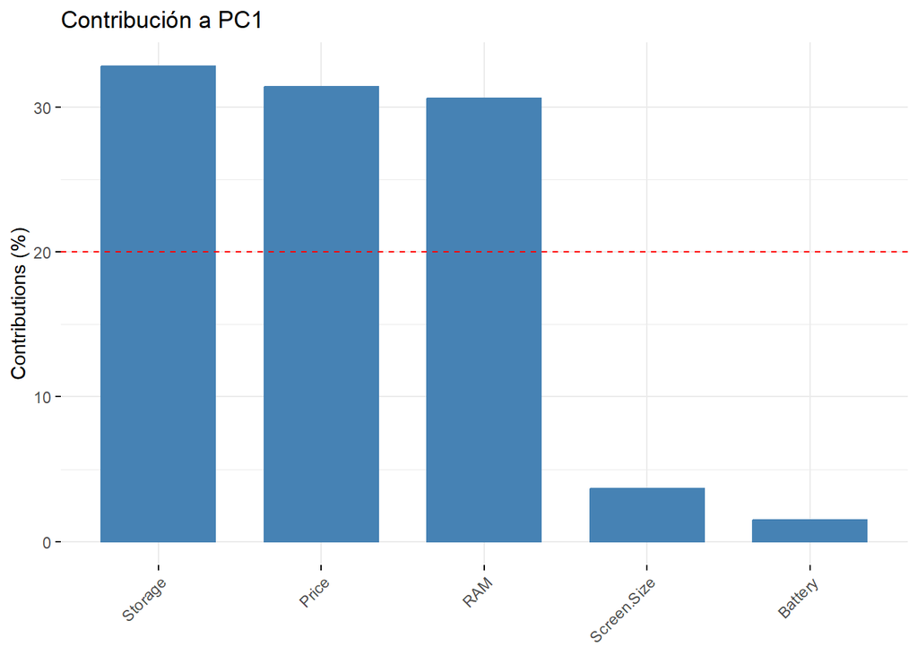

```r
fviz_contrib(datos_pca, choice = "var",axes = 1, fill = "steelblue",color = "steelblue",
             sort.val = "desc",top = Inf,xtickslab.rt = 45,ggtheme = theme_minimal(),
             title = "Contribución a PC1")
```

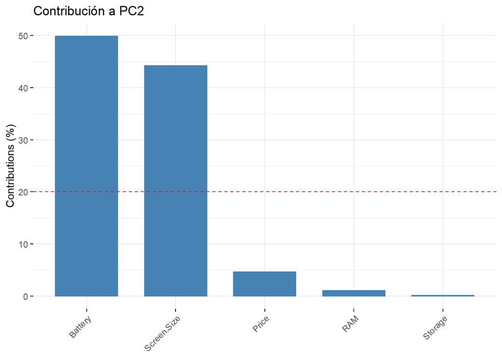

```r
fviz_contrib(datos_pca, choice = "var",axes = 2, fill = "steelblue",color = "steelblue",
             sort.val = "desc",top = Inf,xtickslab.rt = 45,ggtheme = theme_minimal(),
             title = "Contribución a PC2")
```

## 5.3 Representación de las variables

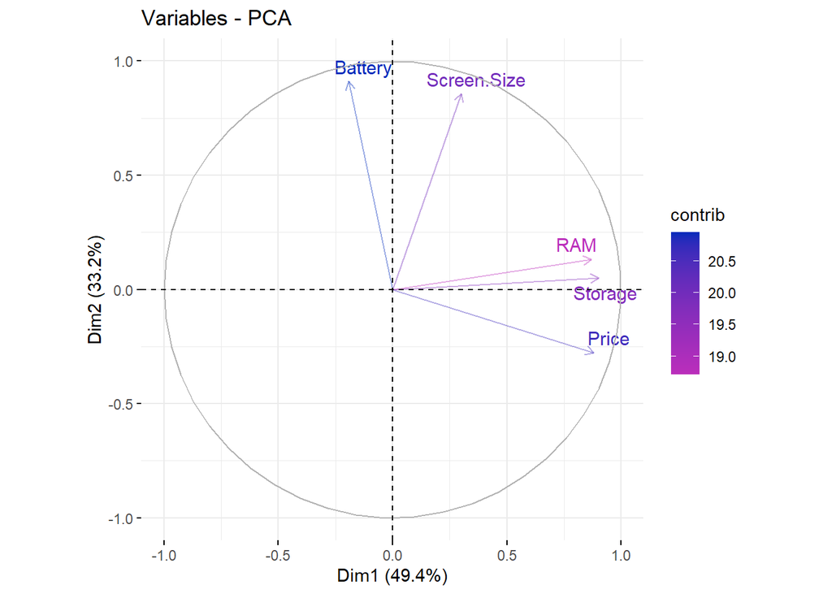

```r
fviz_pca_var(datos_pca, col.var = "contrib",
             gradient.cols = c("#bb2eBB", "#002bbb"),
             repel =TRUE, alpha.var = 0.4)
```

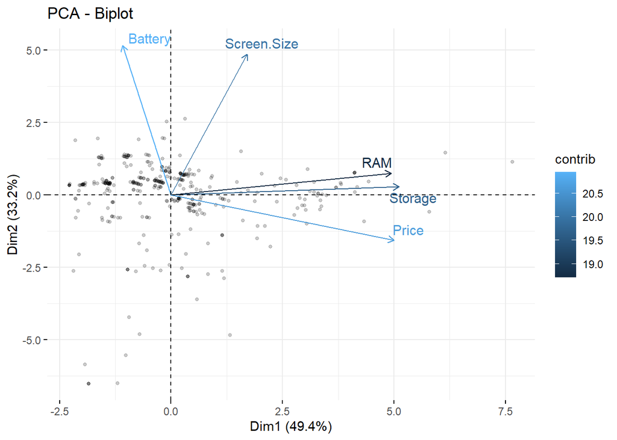

```r
fviz_pca_biplot(datos_pca, repel=TRUE, geom.ind = "point", pointsize = 1, alpha.ind = 0.2,
                col.var ="contrib")
```

## 5.4 Representación por compañía.

En este gráfico se puede ver en que posición se encuentra cada compañía

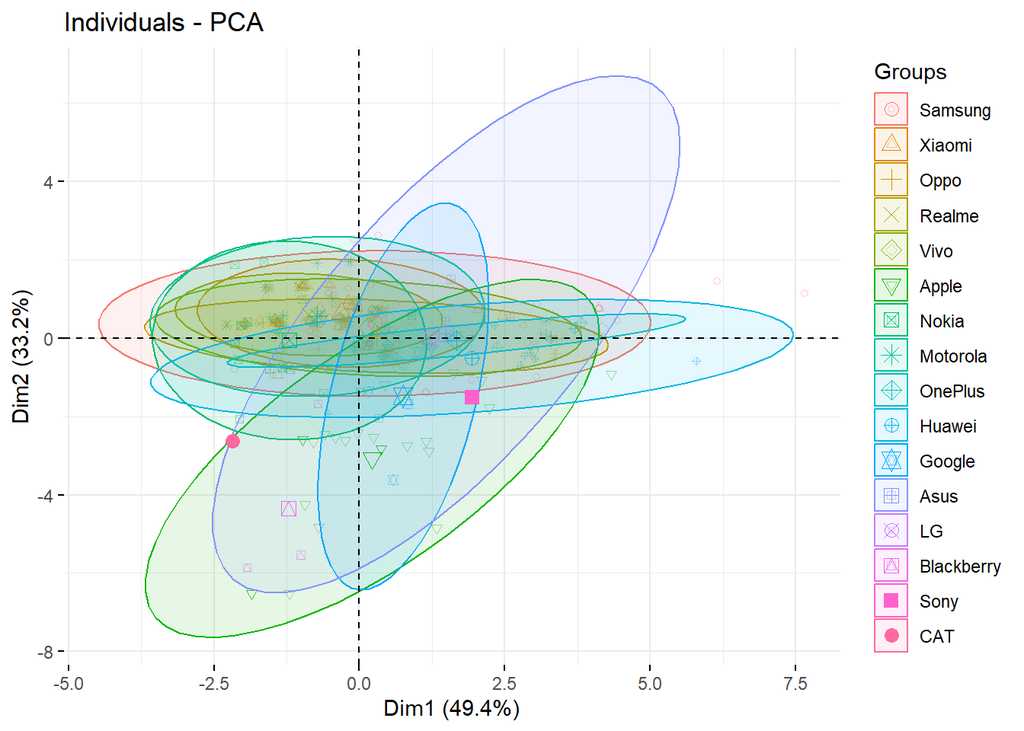

```r
fviz_pca_ind(datos_pca, label = "var", habillage = factor(datos1.2$Brand), addEllipses = TRUE,
             alpha.ind = 0.4)
```